# Ryan_Austin_Unit2_Deliverable2_Q3_1

## 3.1 Linear Regression Model Predicting Mosquito Number

```python
# Data and module/library loading
import matplotlib.pyplot as plt
import numpy as np
import pandas as pd
import seaborn as sns

# Important functionality for this lesson
from scipy import stats
import statsmodels.api as sm

# Setting globally figure size in the notebook
plt.rcParams["figure.figsize"] = (8.0, 6.0)

mosquito_data2_df3 = pd.read_csv(r"C:\Users\raust\OneDrive\Documents\0 BrainStation\BrainStation Data Science\Deliverables\Unit 2 Deliverable 2\mosquito_data_part_2.csv")
```

##### Linear regression models predict a continuous, numeric variable.

##### Before building the model, any categoric variables will have to be identified and converted to a numeric variable.

```python
# To get an overview of the data types available for the model.
mosquito_data2_df3.info()

# The relevant variables will be Year, Week, Lat, Lon, and Mon.
```

```
<class 'pandas.core.frame.DataFrame'>
RangeIndex: 18495 entries, 0 to 18494
Data columns (total 12 columns):
 #   Column           Non-Null Count  Dtype
---  ------           --------------  -----
 0   Year             18495 non-null  int64
 1   Week             18495 non-null  int64
 2   Address Block    18495 non-null  object
 3   Trap             18495 non-null  object
 4   Trap type        18495 non-null  object
 5   Date             18495 non-null  object
 6   Mosquito number  18495 non-null  int64
 7   WNV Present      18495 non-null  object
 8   Species          18495 non-null  object
 9   Lat              18495 non-null  float64
 10  Lon              18495 non-null  float64
 11  Month            18495 non-null  int64
dtypes: float64(2), int64(4), object(6)
memory usage: 1.7+ MB
```

## Preliminary Assessment: Notes Based on Subject Matter Expertise

##### Year: Unless there is a consistent increase, or decrease in mosquito number over the years, it is not clear how "Year" could be used as a *predictive* measure for mosquito count.

##### Week: Mosquito prevalence is seasonal because year by year the weeks of the year are consistent with respect to the climatic conditions favourable to mosquito breeding. Still, "Week" is too granular and would add too much complexity and unnecessary computation for the model. "Month" would be a better proxy for mosquito prevalance time frame.

##### Address Block: A categorical variable that will have to be converted to a numeric variable. Still, the only alternatives are that mosquitos were found at the address or they were not. A given address block would be more useful for a heat map showing gradient than for a regression model predicting mosquito count.

##### Trap: Like "Address Block", "Trap ID" is a categorical variable that is more useful for a heat map than a regression model predicting mosquito count.

##### Trap Type: A given trap type may have captured more mosquitos, giving some insight into which trap to use more often, but trap type is **not** a logical predictor of mosquito count.

##### Date: Even more than "Week", the date timestamp down to the second is too granular and computationally intensive for a regression model. Month is the more practical predictor.

##### WNV Present was specified to not be a part of the model.

##### Species: Species is important to know if any harbour the virus more than others. Its use as a predictor of mosquito count is questionable though. Does the count of one or another species affect the count of a third? In other words, is their coexistence competitive or complementary? How does the marginal increase of one species or another (the individual species would have to represent separate weights in the model) predicted to affect mosquito count?

##### Lat: Without being paired with longitude *as a coordinate* , latitude is not really a credible predictor. However, since it is known that the test area is limited to the Chicago area, knowing latitude should be one of the better predictors of mosquito count.

##### Lon: Longitude is one of the better predictors of mosquito count for the same reasons as latitude, and shares the same limitation.

##### Month: The most practical predictor of when a seasonal species is most prevalent.

#### Conversion of categorical variables to numeric ones.

```python
# Prepare to convert categorical (i.e. object) fields to numerical ones.

mosquito_data2_df3b = mosquito_data2_df3.copy()

from sklearn.preprocessing import OneHotEncoder
```

```python
# Remove the "WNV Present" feature
mosquito_data2_df3c = mosquito_data2_df3b.drop(['WNV Present'], axis=1)

categories_to_make_numerical = mosquito_data2_df3c.select_dtypes(include='object').columns.tolist()

mosquito_data2_ddf3 = pd.get_dummies(mosquito_data2_df3c, columns=categories_to_make_numerical, drop_first=True)

mosquito_data2_ddf3.head()
```

|  | Year | Week | Mosquito number | Lat | Lon | Month | Address Block_100XX W OHARE AIRPORT | Address Block_101XX S STONY ISLAND AVE | Address Block_104XX S OGLESBY AVE | Address Block_104XX S VINCENNES AVE | ... | Date_2019-08-15 00:08:00 | Date_2019-08-22 00:08:00 | Date_2019-08-29 00:08:00 | Date_2019-09-05 00:09:00 | Date_2019-09-12 00:09:00 | Date_2019-09-19 00:09:00 | Date_2019-09-26 00:09:00 | Species_CULEX RESTUANS | Species_CULEX SALINARIUS | Species_CULEX TERRITANS |
| --- | --- | --- | --- | --- | --- | --- | --- | --- | --- | --- | --- | --- | --- | --- | --- | --- | --- | --- | --- | --- | --- |
| 0 | 2019 | 39 | 2 | 41.977738 | -87.880969 | 9 | True | False | False | False | ... | False | False | False | False | False | False | True | True | False | False |
| 1 | 2019 | 39 | 1 | 41.798211 | -87.736925 | 9 | False | False | False | False | ... | False | False | False | False | False | False | True | True | False | False |
| 2 | 2019 | 39 | 2 | 41.987245 | -87.689417 | 9 | False | False | False | False | ... | False | False | False | False | False | False | True | True | False | False |
| 3 | 2019 | 39 | 1 | 41.953664 | -87.724987 | 9 | False | False | False | False | ... | False | False | False | False | False | False | True | True | False | False |
| 4 | 2019 | 39 | 9 | 41.657069 | -87.546049 | 9 | False | False | False | False | ... | False | False | False | False | False | False | True | True | False | False |

5 rows × 651 columns

#### Before building the multiple linear regression model, verify that:

##### 1. There is a linear relationship between the dependent and independent variables

##### 2. There is no multicollinearity between the independent variables

## 1. Check for Linear Relationship

```python
# 3.1 LINEAR REGRESSION MODEL PREDICTING MOSQUITO NUMBER (cont'd)


# 0 What is the correlation of the independent variables with 'Mosquito number'?
mosquito_data2_ddf3_predictors = mosquito_data2_ddf3

mosquito_data_corr = mosquito_data2_ddf3_predictors.corr()['Mosquito number']

# Sort descending to show only the highest and lowest correlations
mosquito_data_corr_sorted = mosquito_data_corr.sort_values(ascending=False)
print(mosquito_data_corr_sorted)
```

```
Mosquito number                        1.000000
Date_2016-07-27 00:07:00               0.157946
Address Block_100XX W OHARE AIRPORT    0.141671
Trap_T002                              0.133303
Address Block_41XX N OAK PARK AVE      0.132908
                                         ...
Trap_T079                             -0.047270
Species_CULEX SALINARIUS              -0.072859
Trap type_GRAVID                      -0.138275
Species_CULEX TERRITANS               -0.150962
Lon                                   -0.151421
Name: Mosquito number, Length: 651, dtype: float64
```

## Initial Assessment

##### The initial results confirm some of the preliminary suspicions about feature usefulness based on subject matter knowledge.

##### The correlations are too weak to include any single Date, Address Block, or Trap ID in the model without including the others.

##### There are only four species, so including three (which would determine the impact of the fourth) could be relatively useful to estimate mosquito count.

##### There are only four trap types, but as stated above, using trap type to predict mosquito count is dubious.

##### Latitude, Longitude, and Month remain the most credible predictors of mosquito count, but those correlations are low as well.

##### A note about the negative correlation of Longitude: For the negative correlations, longitude was strongest, but what does it mean? "West" longitudes are "negative" relative to the Prime Meridian. The result suggests that the further west the sample point (within the Chicaco area), the higher the mosquito count.

## Next Steps

##### Having reasoned why certain features should be used and not others, the focus from now on will be on those features.

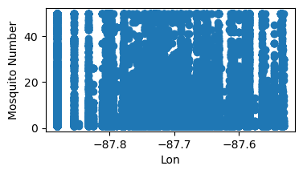

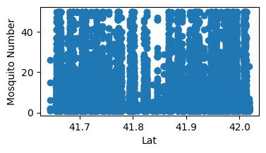

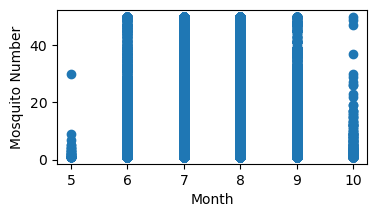

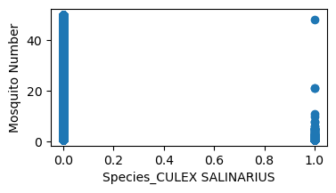

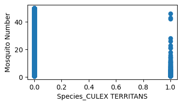

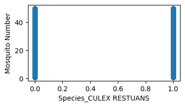

```python
# Check for linear relationship
# Declare X and y variables.
X = mosquito_data2_ddf3_predictors[['Lon', 'Lat', 'Month', 'Species_CULEX SALINARIUS', 'Species_CULEX TERRITANS', 'Species_CULEX RESTUANS']]
# print(X)
y = mosquito_data2_ddf3_predictors['Mosquito number']

# Using a loop to make 6 plots
for column in X.columns:
    plt.figure(figsize=(4, 2))
    plt.scatter(X[column], y)
    plt.ylabel('Mosquito Number')
    plt.xlabel(column)
    plt.show()

# It is clear that none of the numerical independent variables have a linear relationship with number of mosquitos caught.
```

## Linear Relationship Post-Assessment

##### The plots showed no evidence of a linear relationship with "Mosquito Number" at all.

##### Note: The plots did not necessarily represent the highest correlating features, but "Lon" and the C. Territans species were comparable to the highest correlating feature (albeit negatively so). No other linear relationship plot would show more of a linear relationship.

## 2. Check for Multicollinearity

##### Multicolinearity introduces redundancy in the model. A correlation matrix among the predictor variables would identify multicollinearity.

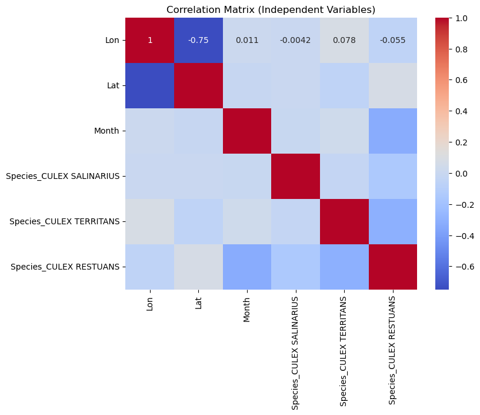

```python
# Testing for multicollinearity among the independent variables.
corr_mat = X.corr()

# Heatmap for visualization
sns.heatmap(corr_mat, annot=True, cmap='coolwarm')
plt.title('Correlation Matrix (Independent Variables)')
plt.show()

# Latitude values are necessily positive, and longitude values are necessily negative, but it is unclear why there should be a strong relationship at all w.r.t. Mosquito number.
```

## The Linear Regression Model

```python
# Add a constant to the model
X_with_constant = sm.add_constant(X)

# 1. Instantiate Model
mosquito_count_model = sm.OLS(y, X_with_constant)

# 2. Fit Model (this returns a seperate object with the parameters)
mosquito_count_model_fitted = mosquito_count_model.fit()

# Looking at the summary
mosquito_count_model_fitted.summary()
```

[output not shown]

[output cut: 17 more lines]

[output not shown]

##### The following error was triggered:

##### ValueError: Pandas data cast to numpy dtype of object. Check input data with np.asarray(data).

##### All the variables are already dummy variables.

##### An extra step will be taking by encoding the boolean ones as "0" or "1".

```python
# Ensure boolean values are replaced with binary digits
X_bit = X.replace({True: 1, False: 0})
```

```python
# Reattempt the model.
# Add a constant to the model
X_with_constant = sm.add_constant(X_bit)

# 1. Instantiate Model
mosquito_count_model = sm.OLS(y, X_with_constant)

# 2. Fit Model (this returns a seperate object with the parameters)
mosquito_count_model_fitted = mosquito_count_model.fit()

# Looking at the summary
mosquito_count_model_fitted.summary()
```

OLS Regression Results

| Dep. Variable: | Mosquito number | R-squared: | 0.050 |
| --- | --- | --- | --- |
| Model: | OLS | Adj. R-squared: | 0.050 |
| Method: | Least Squares | F-statistic: | 163.0 |
| Date: | Sun, 09 Nov 2025 | Prob (F-statistic): | 1.21e-202 |
| Time: | 22:28:29 | Log-Likelihood: | -73869. |
| No. Observations: | 18495 | AIC: | 1.478e+05 |
| Df Residuals: | 18488 | BIC: | 1.478e+05 |
| Df Model: | 6 |  |  |
| Covariance Type: | nonrobust |  |  |

|  | coef | std err | t | P>\|t\| | [0.025 | 0.975] |
| --- | --- | --- | --- | --- | --- | --- |
| const | -1895.8036 | 101.007 | -18.769 | 0.000 | -2093.786 | -1697.821 |
| Lon | -23.9565 | 1.532 | -15.642 | 0.000 | -26.958 | -20.955 |
| Lat | -4.5474 | 1.266 | -3.592 | 0.000 | -7.029 | -2.066 |
| Month | -0.4843 | 0.103 | -4.704 | 0.000 | -0.686 | -0.283 |
| Species_CULEX SALINARIUS | -9.5658 | 0.894 | -10.704 | 0.000 | -11.317 | -7.814 |
| Species_CULEX TERRITANS | -8.7724 | 0.471 | -18.620 | 0.000 | -9.696 | -7.849 |
| Species_CULEX RESTUANS | -0.0543 | 0.229 | -0.238 | 0.812 | -0.502 | 0.394 |

| Omnibus: | 4929.200 | Durbin-Watson: | 1.507 |
| --- | --- | --- | --- |
| Prob(Omnibus): | 0.000 | Jarque-Bera (JB): | 10276.743 |
| Skew: | 1.605 | Prob(JB): | 0.00 |
| Kurtosis: | 4.740 | Cond. No. | 1.02e+05 |

Notes:  
[1] Standard Errors assume that the covariance matrix of the errors is correctly specified.  
[2] The condition number is large, 1.02e+05. This might indicate that there are  
strong multicollinearity or other numerical problems.

## 3. Check for Normalcy of Residual Distribution

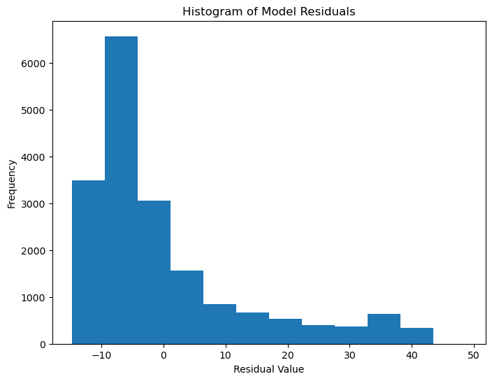

```python
# Examine the distribution of the residuals
model_resids = mosquito_count_model_fitted.resid

# Fitted values are the predicted Y for each input row of independent variables.
# These values are also in the results object
model_fittedvals = mosquito_count_model_fitted.fittedvalues

plt.figure()

plt.hist(model_resids, bins=12)

plt.xlabel("Residual Value")
plt.ylabel("Frequency")
plt.title("Histogram of Model Residuals")
plt.show()

# The residuals are clearly not normally distributed.
```

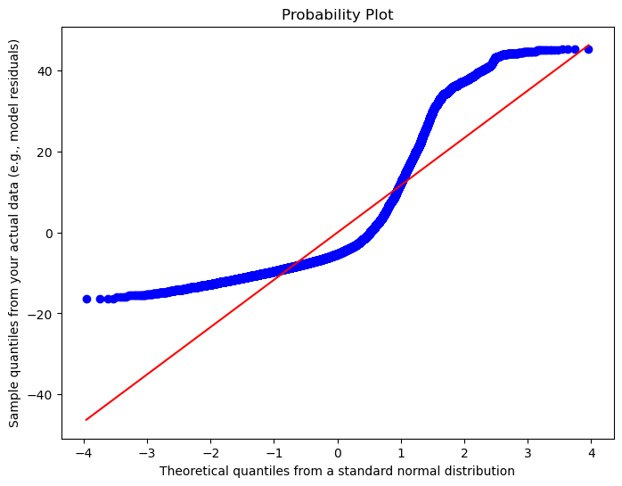

```python
# Another approach would be the Normal Q-Q plot
plt.figure()
stats.probplot(model_resids, dist="norm", plot=plt)
plt.xlabel("Theoretical quantiles from a standard normal distribution")
plt.ylabel("Sample quantiles from your actual data (e.g., model residuals)")
plt.show()

# More evidence that the residuals are not normally distributed.
```

## Residual Distribution Post-Analysis

##### The model is not capturing the full range of the variation in the data. That was evident from the 0.05 R^2

##### Factors include:

##### 1. The omission of important variables,

##### 2. Non-linear relationships,

##### 3. Misspecification of the functional form of the model.

##### The first one was suspected from the preliminary analsis.

##### The second one was demonstrated with scatterplots and correlation analyses.

##### I cannot speak to the third possible cause without addressing the first two.

## 4. Check for Homoscedasticity of Residual Distribution

##### Whether the residuals have a constant variance across all ranges of predicted values.

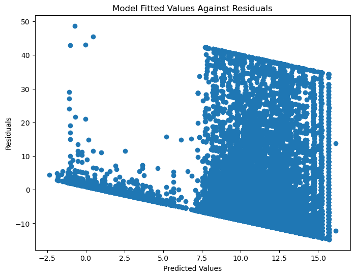

```python
# 3.1 LINEAR REGRESSION MODEL PREDICTING MOSQUITO NUMBER (cont'd)

# Test for homoscedasticity
plt.figure()

plt.scatter(model_fittedvals, model_resids)

plt.xlabel('Predicted Values')
plt.ylabel('Residuals')
plt.title("Model Fitted Values Against Residuals")

plt.show()

# Again, not normally distributed. A linear regression model should not be build from this data.
```

## Homoscedasticity Check Post-Assessment

##### The residuals do not have a constant variance.

## Conclusions

##### This model should **NOT** be used for mosquito count prediction.

##### More data from relevant features is needed.